# STAT_5405_HW_6

2023-10-13

##1a.

Dataset deforestation, contains the information about the forest cover data belongs to 4 provinces of China. We were trying to figure out the reason behind the rapid deforestation on basis of the 17 predictors to one response variable called $fcover$ by drawing a relataion ship between the explanatory and response variable

```r
library(tidyverse)
data1 <- read.csv("Data/deforest.csv", header = TRUE)
data2 <- data1
str(data1)
```

```
## 'data.frame':    405 obs. of  21 variables:
##  $ id      : int  1 2 3 4 5 6 7 8 9 10 ...
##  $ code    : int  360121 360122 360123 360124 360222 360281 360321 360421 360423 360424 ...
##  $ ename   : chr  "nanchangxian" "xinjian" "anyi" "jinxian" ...
##  $ fcover  : num  3.1 39.3 23.7 38.7 265.3 ...
##  $ tpop    : int  93 67 26 77 27 82 25 34 37 81 ...
##  $ apop    : int  74 59 19 65 23 66 22 28 30 68 ...
##  $ gdp1    : num  2820 2819 2101 2387 2199 ...
##  $ gdp2    : num  9744 6301 3968 6314 3454 ...
##  $ gdp3    : num  3898 5167 4868 3502 2633 ...
##  $ distpvc : num  21261 33245 37651 46479 168570 ...
##  $ distport: num  435763 453378 489739 407609 366528 ...
##  $ hwaylen : num  28750 13619 26491 54050 129788 ...
##  $ explen  : num  21420 2173 8122 16306 11674 ...
##  $ plain   : num  0.9222 0.6664 0.3792 0.5128 0.0878 ...
##  $ elev    : int  19 30 70 28 190 76 415 63 334 377 ...
##  $ prec    : int  1569 1521 1571 1619 1758 1758 1597 1560 1505 1591 ...
##  $ slope   : num  0.07 0.33 1.49 0.28 2.91 1.17 4.05 1.14 4.78 4.59 ...
##  $ temp    : num  17.5 17.2 16.8 17.5 16 17.2 15.8 16.7 15.1 15 ...
##  $ temp0   : num  6384 6290 6136 6424 5857 ...
##  $ area    : int  188635 234934 65605 194959 329200 197469 106237 90523 367767 433093 ...
##  $ policy  : int  0 1 0 1 0 0 0 0 1 1 ...
```

Lets first satisfy the normality and variance assumptions on the response variable so that we can proceed further with the analysis on the data by fitting the multiple linear regression.

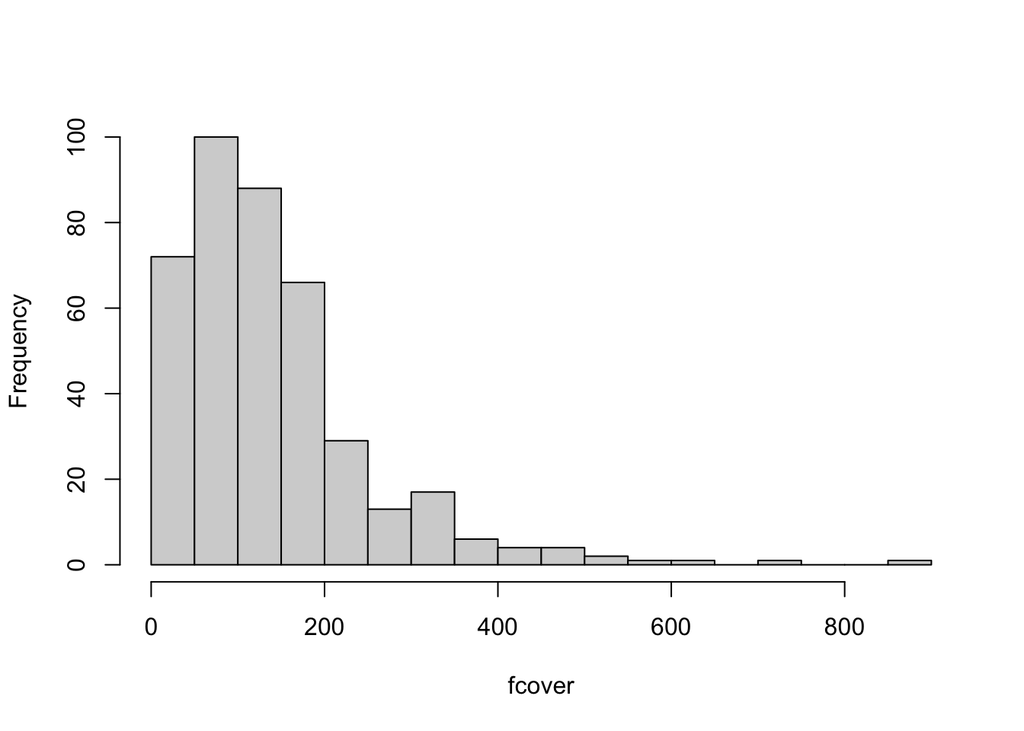

```r
library(e1071)
hist(data1$fcover, breaks=30, main="", xlab="fcover")
```

```r
shapiro.test(data1$fcover)
```

```
##
##  Shapiro-Wilk normality test
##
## data:  data1$fcover
## W = 0.84914, p-value < 2.2e-16
```

```r
skewness(data1$fcover)
```

```
## [1] 1.977274
```

We can observe that the data is **not satisfying the normality with the fcover** data as the data is right skewed which was confirmed statistically through the shapiro-wilk test - pvalue(which is less than the significance level).

I have applied log transformation to the fcover variable to check for the normality assumption

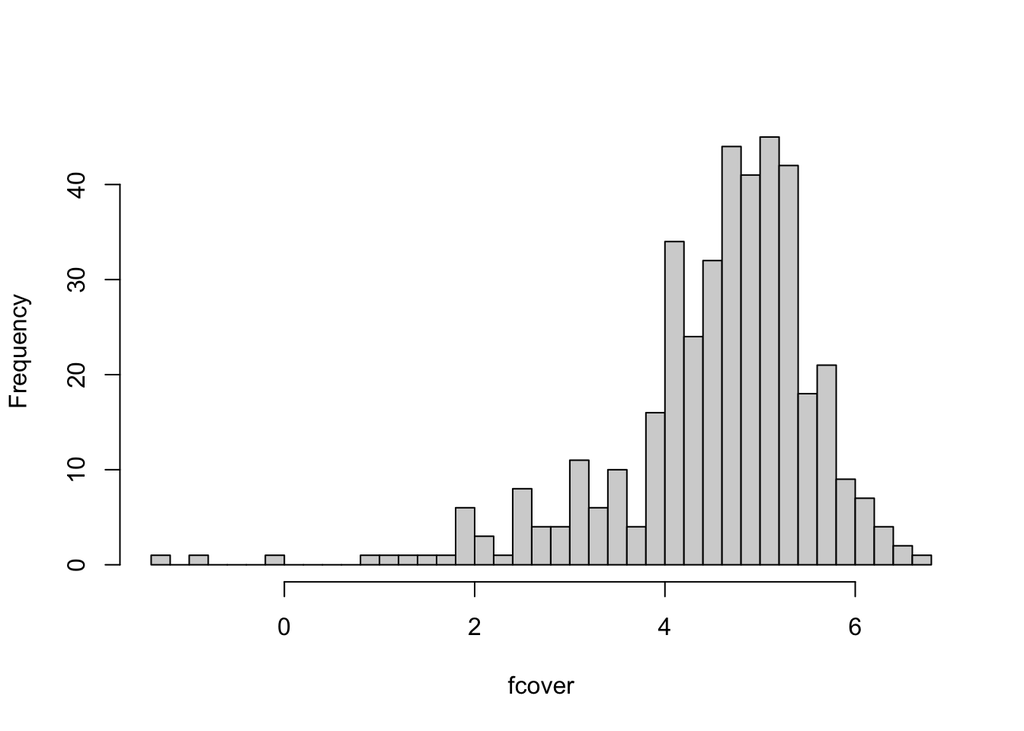

```r
hist(log(data1$fcover), breaks=30, main="", xlab="fcover")
```

```r
library(e1071)
shapiro.test(log(data1$fcover))
```

```
##
##  Shapiro-Wilk normality test
##
## data:  log(data1$fcover)
## W = 0.89572, p-value = 5.311e-16
```

```r
skewness(log(data1$fcover))
```

```
## [1] -1.563911
```

Following is the code to fit the MLR model on top of the log transformed response variable with respective to all the predictor variables. Data was splitted with the train and test data sets on the proportion of 80% and 20% respectively and the data was standardized on the train data by mean.

```r
data1$logfcover <- log(data1$fcover)

set.seed(87654)
train.prop <- 0.80
trnset <- sort(sample(1:nrow(data1), ceiling(nrow(data1)*train.prop)))
# create the training and test sets
train.set <- data1[trnset, ]
test.set  <- data1[-trnset, ]

library(caret)
contpredcols <- 5:20
# Find mean and std dev of train.set.1
normParam <- preProcess(train.set[,contpredcols],
                        method = c("center", "scale"))
# standardize the training set based on its mean and std
data.train <- cbind(train.set[,c("logfcover", "policy")],
                    predict(normParam, train.set[,contpredcols]))
# standardize test set based on the above mean and std dev of training set
data.test <- cbind(test.set[,c("logfcover", "policy")],
                   predict(normParam, test.set[,5:20]))

mod.log <- lm(logfcover ~., data = data.train)
summary(mod.log)
```

```
##
## Call:
## lm(formula = logfcover ~ ., data = data.train)
##
## Residuals:
##      Min       1Q   Median       3Q      Max
## -2.53762 -0.27936  0.07262  0.36022  1.24238
##
## Coefficients:
##              Estimate Std. Error t value Pr(>|t|)
## (Intercept)  4.445392   0.055761  79.722  < 2e-16 ***
## policy       0.101974   0.074142   1.375  0.17002
## tpop         0.265778   0.171795   1.547  0.12288
## apop        -0.269560   0.168553  -1.599  0.11079
## gdp1         0.063386   0.036797   1.723  0.08597 .
## gdp2        -0.165013   0.037840  -4.361 1.77e-05 ***
## gdp3        -0.033722   0.032735  -1.030  0.30376
## distpvc      0.205538   0.098959   2.077  0.03864 *
## distport    -0.627542   0.058441 -10.738  < 2e-16 ***
## hwaylen     -0.207397   0.098895  -2.097  0.03680 *
## explen      -0.004414   0.034629  -0.127  0.89866
## plain       -0.115945   0.040826  -2.840  0.00481 **
## elev         0.138862   0.096908   1.433  0.15290
## prec         0.126751   0.061440   2.063  0.03996 *
## slope        0.592272   0.057393  10.320  < 2e-16 ***
## temp         1.390057   0.447798   3.104  0.00209 **
## temp0       -1.254409   0.440308  -2.849  0.00468 **
## area         0.711989   0.056768  12.542  < 2e-16 ***
## ---
## Signif. codes:  0 '***' 0.001 '**' 0.01 '*' 0.05 '.' 0.1 ' ' 1
##
## Residual standard error: 0.5552 on 306 degrees of freedom
## Multiple R-squared:  0.7595, Adjusted R-squared:  0.7462
## F-statistic: 56.85 on 17 and 306 DF,  p-value: < 2.2e-16
```

With the extremely small p-values illustrates us the relationship of the response variable with the explanatory variable and the **75% of response variable is explained by the predictor variables** which we can confirmed by the multiple R-squared value and also we can observe the regression co-efficient values of each variable where negative sign indicates that they are negatively co-related and positive indicates that they are positively co-related.

below plot is for the predicted values of the above model that we fitted and we can observe that the data predicted was not normal

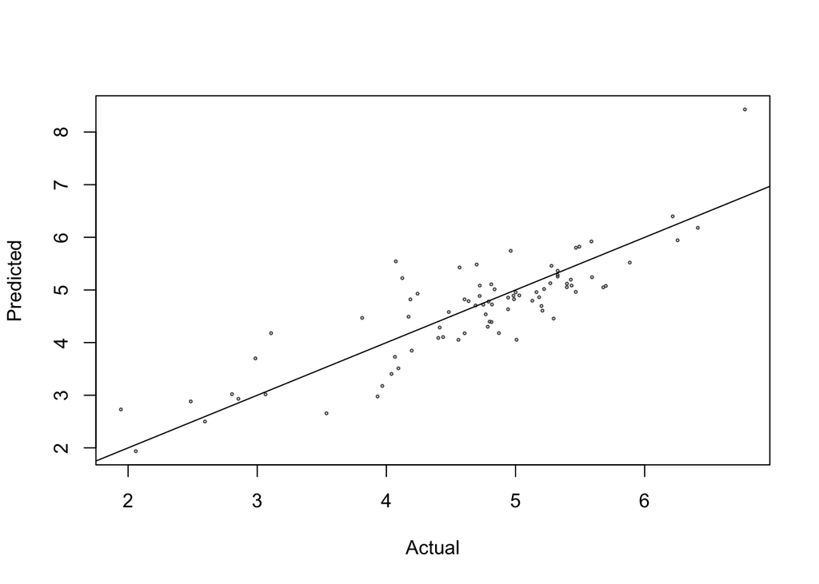

```r
plot(data.test$logfcover, predict(mod.log, newdata = data.test),
     col="grey33", cex=0.3, xlab="Actual", ylab="Predicted")
abline(0,1)
```

Following is the code to fit the data for the normality assumption by applying square root

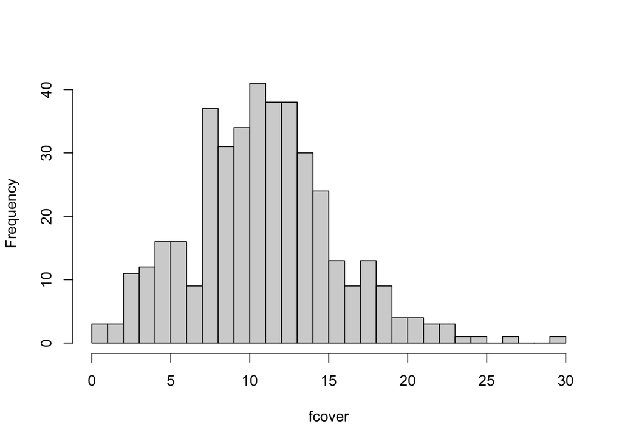

```r
hist(sqrt(data1$fcover), breaks=30, main="", xlab="fcover")
```

```r
library(e1071)
shapiro.test(sqrt(data1$fcover))
```

```
##
##  Shapiro-Wilk normality test
##
## data:  sqrt(data1$fcover)
## W = 0.98549, p-value = 0.0004441
```

```r
skewness(sqrt(data1$fcover))
```

```
## [1] 0.4269692
```

From the above bar graph we can observe that the **data is not normally distributed** however by applying the shapiro-wilk test it rejects the null hypothesis of normally distributed.

Following is the code to fit the data to multiple linear regression on the sqaure root of the fcover vairable as the response variable

```r
data1$sqrtfcover <- sqrt(data1$fcover)

set.seed(87654)
train.prop <- 0.80
trnset <- sort(sample(1:nrow(data1), ceiling(nrow(data1)*train.prop)))
# create the training and test sets
train.set <- data1[trnset, ]
test.set  <- data1[-trnset, ]

library(caret)
contpredcols <- 5:20
# Find mean and std dev of train.set.1
normParam <- preProcess(train.set[,contpredcols],
                        method = c("center", "scale"))
# standardize the training set based on its mean and std
data.train <- cbind(train.set[,c("sqrtfcover", "policy")],
                    predict(normParam, train.set[,contpredcols]))
# standardize test set based on the above mean and std dev of training set
data.test <- cbind(test.set[,c("sqrtfcover", "policy")],
                   predict(normParam, test.set[,5:20]))

mod.1 <- lm(sqrtfcover ~., data = data.train)
summary(mod.1)
```

```
##
## Call:
## lm(formula = sqrtfcover ~ ., data = data.train)
##
## Residuals:
##      Min       1Q   Median       3Q      Max
## -13.0552  -0.9891   0.0826   1.1550   5.2465
##
## Coefficients:
##               Estimate Std. Error t value Pr(>|t|)
## (Intercept)  10.868968   0.196141  55.414  < 2e-16 ***
## policy       -0.223861   0.260796  -0.858 0.391357
## tpop          0.826608   0.604295   1.368 0.172351
## apop         -1.123415   0.592889  -1.895 0.059059 .
## gdp1         -0.004888   0.129433  -0.038 0.969899
## gdp2         -0.069523   0.133105  -0.522 0.601825
## gdp3         -0.081145   0.115147  -0.705 0.481529
## distpvc       0.302879   0.348092   0.870 0.384922
## distport     -1.637127   0.205567  -7.964 3.30e-14 ***
## hwaylen      -0.385816   0.347867  -1.109 0.268262
## explen       -0.013008   0.121810  -0.107 0.915025
## plain        -0.538631   0.143607  -3.751 0.000211 ***
## elev          0.013479   0.340877   0.040 0.968484
## prec          0.451529   0.216116   2.089 0.037507 *
## slope         2.146671   0.201883  10.633  < 2e-16 ***
## temp         11.642760   1.575142   7.392 1.40e-12 ***
## temp0       -10.355381   1.548797  -6.686 1.09e-10 ***
## area          4.243368   0.199684  21.250  < 2e-16 ***
## ---
## Signif. codes:  0 '***' 0.001 '**' 0.01 '*' 0.05 '.' 0.1 ' ' 1
##
## Residual standard error: 1.953 on 306 degrees of freedom
## Multiple R-squared:  0.8241, Adjusted R-squared:  0.8143
## F-statistic: 84.32 on 17 and 306 DF,  p-value: < 2.2e-16
```

With the extremely small p-values illustrates us the relationship of the response variable with the explanatory variable and the 82.41% of response variable is explained by the predictor variables which we can confirmed by the multiple R-squared value and also we can observe the regression co-efficient values of each variable where negative sign indicates that they are negatively co-related and positive indicates that they are positively co-related.

below plot is for the predicted values of the above model that we fitted and we can observe that the predicted values are normal.

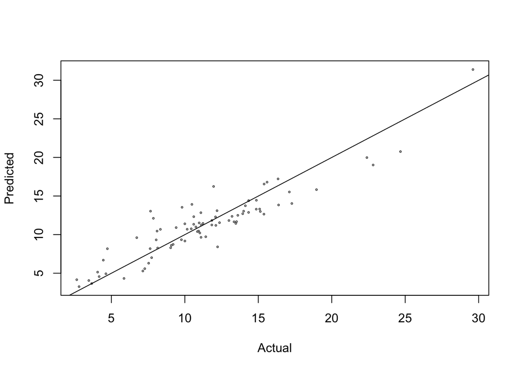

```r
plot(data.test$sqrtfcover, predict(mod.1, newdata = data.test),
     col="grey33", cex=0.3, xlab="Actual", ylab="Predicted")
abline(0,1)
```

From the above two models with the log transformed data and the square root data normality assumption did not satisfy for both of them even though the p-values were same for both it is clear that the **goodness of fit is more with the square rooted response variable with the value of 82.4% when compared to the log transformation with the 74.62%**. However, more the r-squared indicates the over fitting the model where we need to verify other factors such as co-linearity, ouliers, leverages points and further diagnostics on the residuals. Predicted values lies close to the normal line for the square rooted values where as log transformed does not seem to be linear.

1.b.

Following is the code implementation of the box-cox transformation on the response variable.

```r
library(MASS)
boxcox.out <- boxcox(lm(fcover ~ 1, data = data2))
```

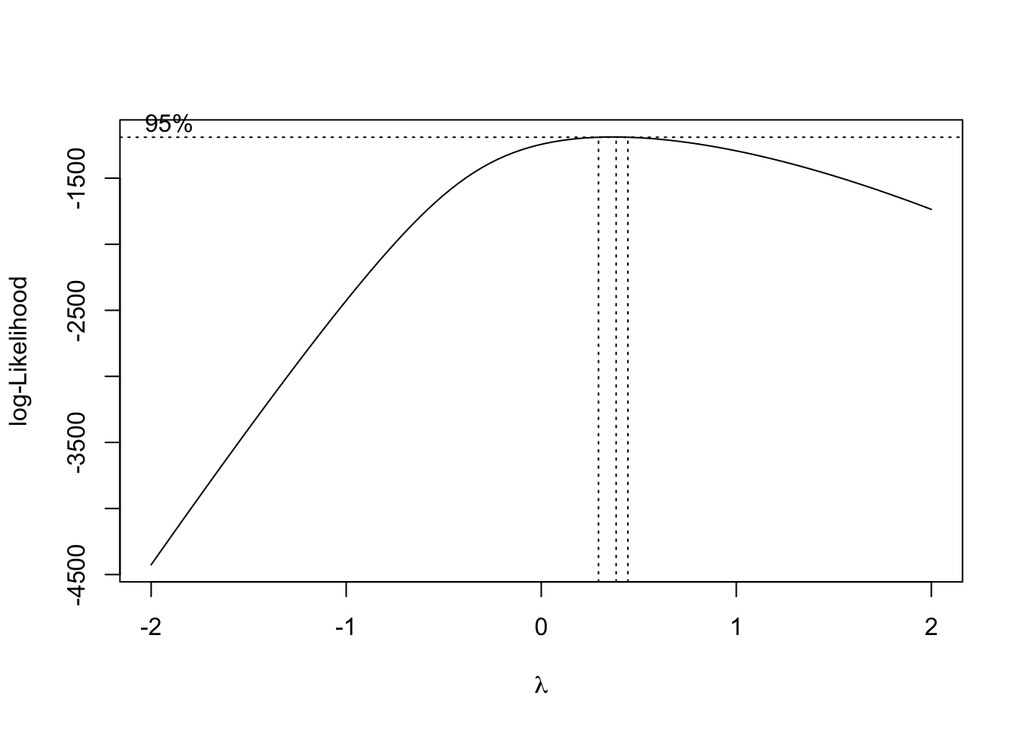

```r
(lambda <- boxcox.out$x[which.max(boxcox.out$y)])
```

```
## [1] 0.3838384
```

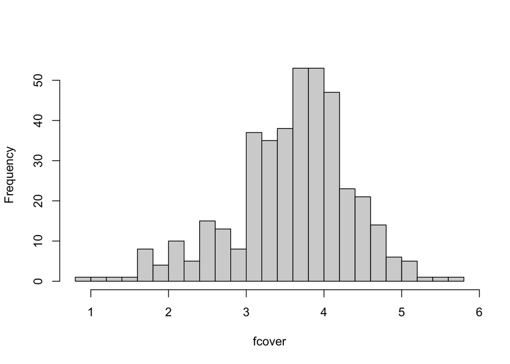

```r
data2$boxcoxfcover <- (data2$fcover^lambda -1)/lambda


hist(sqrt(data2$boxcoxfcover), breaks=30, main="", xlab="fcover")
```

```r
library(e1071)
shapiro.test(data2$boxcoxfcover)
```

```
##
##  Shapiro-Wilk normality test
##
## data:  data2$boxcoxfcover
## W = 0.99365, p-value = 0.08752
```

```r
skewness(data2$boxcoxfcover)
```

```
## [1] 0.06067338
```

**Normality assumption on the response variables is satisfied using the box-cox transformation** which we confirmed statistically from above plots and significant test.

```r
set.seed(87654)
train.prop <- 0.80
trnset <- sort(sample(1:nrow(data2), ceiling(nrow(data2)*train.prop)))
# create the training and test sets
train.set <- data2[trnset, ]
test.set  <- data2[-trnset, ]

library(caret)
contpredcols <- 5:20
# Find mean and std dev of train.set.1
normParam <- preProcess(train.set[,contpredcols],
                        method = c("center", "scale"))
# standardize the training set based on its mean and std
data.train <- cbind(train.set[,c("boxcoxfcover", "policy")],
                    predict(normParam, train.set[,contpredcols]))
# standardize test set based on the above mean and std dev of training set
data.test <- cbind(test.set[,c("boxcoxfcover", "policy")],
                   predict(normParam, test.set[,5:20]))

mod.2 <- lm(boxcoxfcover ~., data = data.train)
summary(mod.2)
```

```
##
## Call:
## lm(formula = boxcoxfcover ~ ., data = data.train)
##
## Residuals:
##     Min      1Q  Median      3Q     Max
## -13.901  -1.312   0.198   1.568   6.008
##
## Coefficients:
##               Estimate Std. Error t value Pr(>|t|)
## (Intercept)  13.288493   0.232521  57.150  < 2e-16 ***
## policy       -0.111236   0.309167  -0.360 0.719249
## tpop          1.109306   0.716376   1.548 0.122536
## apop         -1.398046   0.702854  -1.989 0.047581 *
## gdp1          0.060404   0.153440   0.394 0.694100
## gdp2         -0.203812   0.157792  -1.292 0.197453
## gdp3         -0.116596   0.136504  -0.854 0.393684
## distpvc       0.467044   0.412654   1.132 0.258602
## distport     -2.201728   0.243695  -9.035  < 2e-16 ***
## hwaylen      -0.537320   0.412387  -1.303 0.193571
## explen       -0.009173   0.144402  -0.064 0.949392
## plain        -0.647045   0.170242  -3.801 0.000174 ***
## elev          0.138259   0.404100   0.342 0.732480
## prec          0.540895   0.256200   2.111 0.035564 *
## slope         2.639823   0.239327  11.030  < 2e-16 ***
## temp         12.304222   1.867290   6.589 1.93e-10 ***
## temp0       -10.956030   1.836059  -5.967 6.67e-09 ***
## area          4.711518   0.236721  19.903  < 2e-16 ***
## ---
## Signif. codes:  0 '***' 0.001 '**' 0.01 '*' 0.05 '.' 0.1 ' ' 1
##
## Residual standard error: 2.315 on 306 degrees of freedom
## Multiple R-squared:  0.8207, Adjusted R-squared:  0.8107
## F-statistic: 82.38 on 17 and 306 DF,  p-value: < 2.2e-16
```

Below plot is for the predicted values of the above model that we fitted and we can observe that the predicted values are normal.

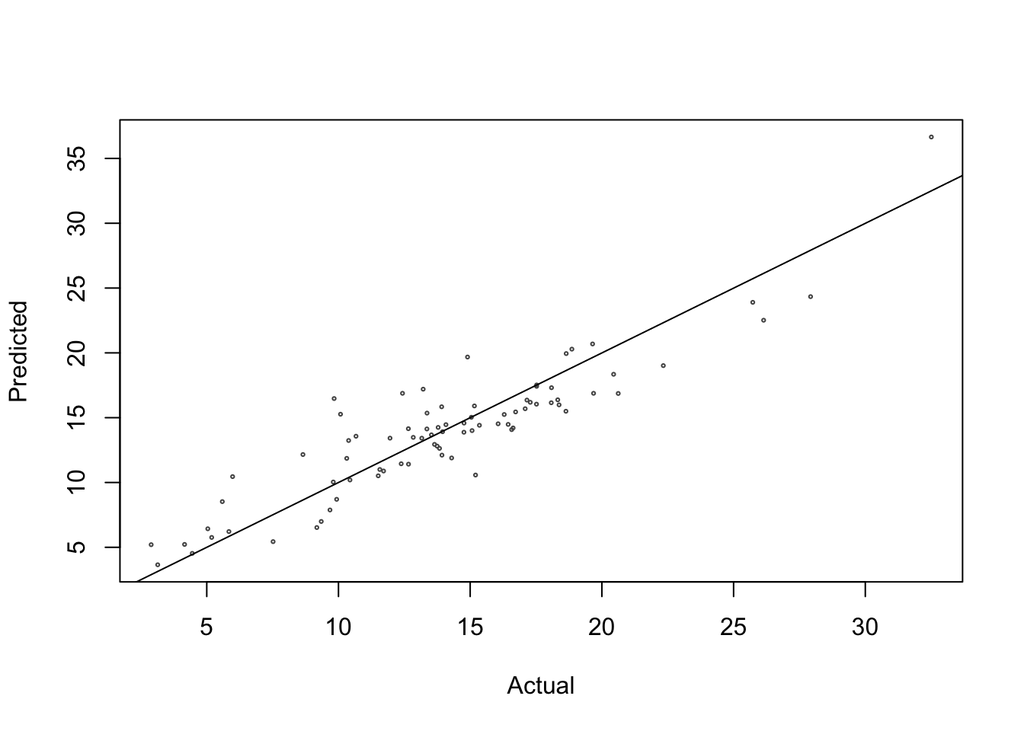

```r
plot(data.test$boxcoxfcover, predict(mod.2, newdata = data.test),
     col="grey33", cex=0.3, xlab="Actual", ylab="Predicted")
abline(0,1)
```

2.

Waste dataset contains total of 6 variables where Solidwatse is the response variable whereas the rest are the predictor variables. There are total of 40 observations and indicates the data of each variable contributing to the SolidWaste.

```r
library("RobStatTM")
data("waste")
str(waste)
```

```
## 'data.frame':    40 obs. of  6 variables:
##  $ Land       : int  102 1220 139 221 12 1 1046 2032 895 0 ...
##  $ Metals     : int  69 723 138 637 0 50 127 44 54 0 ...
##  $ Trucking   : int  133 2616 46 153 1 3 313 409 168 2 ...
##  $ Retail     : int  125 953 35 115 9 25 392 540 117 0 ...
##  $ Restaurants: int  36 132 6 16 1 2 56 98 32 1 ...
##  $ SolidWaste : num  0.357 1.967 0.186 0.382 0.151 ...
```

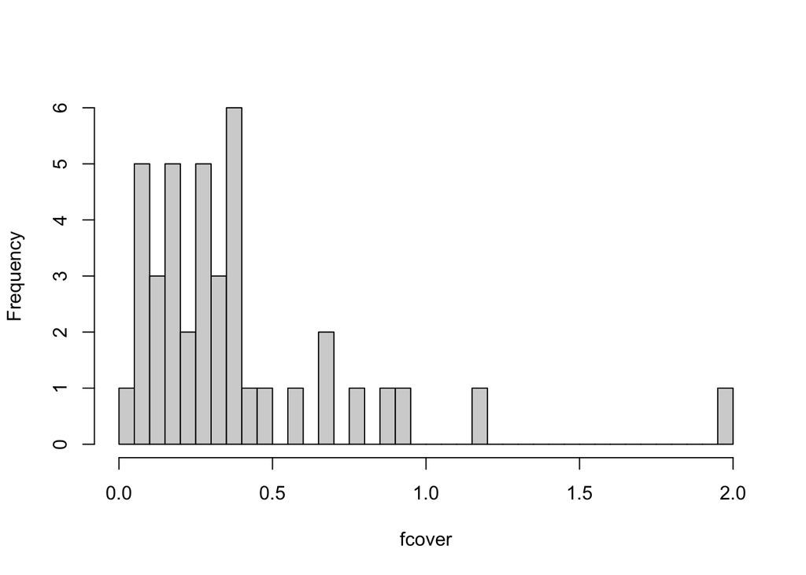

```r
library(e1071)
hist(waste$SolidWaste, breaks=30, main="", xlab="fcover")
```

```r
waste$SolidWaster <- as.numeric(waste$SolidWaste)
shapiro.test(waste$SolidWaste)
```

```
##
##  Shapiro-Wilk normality test
##
## data:  waste$SolidWaste
## W = 0.73803, p-value = 4.348e-07
```

```r
skewness(waste$SolidWaste)
```

```
## [1] 2.424377
```

From the above plot we can observe that the data is **not satisfying the normality assumption** on the response variable and was confirmed by the shapiro wilk test.

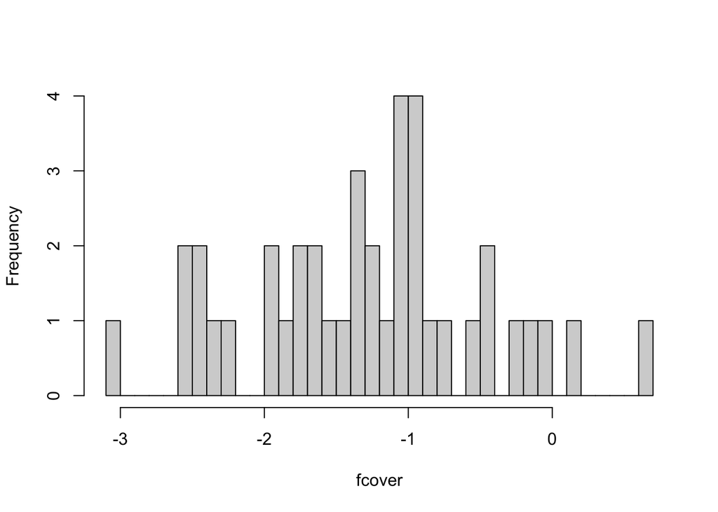

```r
library(e1071)
hist(log(waste$SolidWaste), breaks=30, main="", xlab="fcover")
```

```r
waste$SolidWaster <- as.numeric(waste$SolidWaste)
shapiro.test(log(waste$SolidWaste))
```

```
##
##  Shapiro-Wilk normality test
##
## data:  log(waste$SolidWaste)
## W = 0.98884, p-value = 0.9574
```

```r
skewness(log(waste$SolidWaste))
```

```
## [1] 0.06997491
```

From the above plot we can observe that the **data is satisfying the normality assumption on the log transformation** of response variable and was confirmed by the Shapiro wilk test.

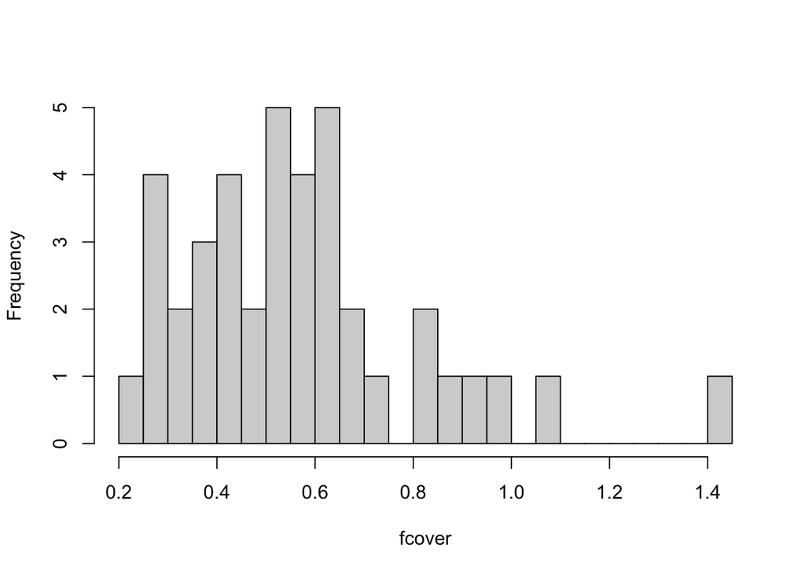

```r
library(e1071)
hist(sqrt(waste$SolidWaste), breaks=30, main="", xlab="fcover")
```

```r
waste$SolidWaster <- as.numeric(waste$SolidWaste)
shapiro.test(sqrt(waste$SolidWaste))
```

```
##
##  Shapiro-Wilk normality test
##
## data:  sqrt(waste$SolidWaste)
## W = 0.9132, p-value = 0.004737
```

```r
skewness(sqrt(waste$SolidWaste))
```

```
## [1] 1.184919
```

From the above plot we can observe that the data is not satisfying the normality assumption on the square root transformation of response variable and was confirmed by the Shapiro wilk test.

```r
waste$SolidWaste <- log(waste$SolidWaste)

mod.waste <- lm(SolidWaste ~ Land + Metals + Trucking + Retail + Restaurants, data = waste)
summary(mod.waste)
```

```
##
## Call:
## lm(formula = SolidWaste ~ Land + Metals + Trucking + Retail +
##     Restaurants, data = waste)
##
## Residuals:
##      Min       1Q   Median       3Q      Max
## -1.00085 -0.21602 -0.01193  0.25561  1.09351
##
## Coefficients:
##               Estimate Std. Error t value Pr(>|t|)
## (Intercept) -1.860e+00  1.034e-01 -17.984  < 2e-16 ***
## Land        -7.576e-05  5.846e-05  -1.296   0.2038
## Metals       1.191e-03  5.016e-04   2.374   0.0234 *
## Trucking    -1.266e-04  2.890e-04  -0.438   0.6642
## Retail      -3.206e-03  1.228e-03  -2.610   0.0134 *
## Restaurants  3.752e-02  7.447e-03   5.038 1.53e-05 ***
## ---
## Signif. codes:  0 '***' 0.001 '**' 0.01 '*' 0.05 '.' 0.1 ' ' 1
##
## Residual standard error: 0.4911 on 34 degrees of freedom
## Multiple R-squared:  0.6841, Adjusted R-squared:  0.6376
## F-statistic: 14.72 on 5 and 34 DF,  p-value: 1.073e-07
```

With the extremely small p-values illustrates us the relationship of the response variable with the explanatory variable and the 68.41% of response variable is explained by the predictor variables which we can confirmed by the multiple R-squared value and also we can observe the regression co-efficient values of each variable where negative sign indicates that they are negatively co-related and positive indicates that they are positively co-related. land, trucking, retail where negatively co related whereas the restaturants and metals were postively co-related.

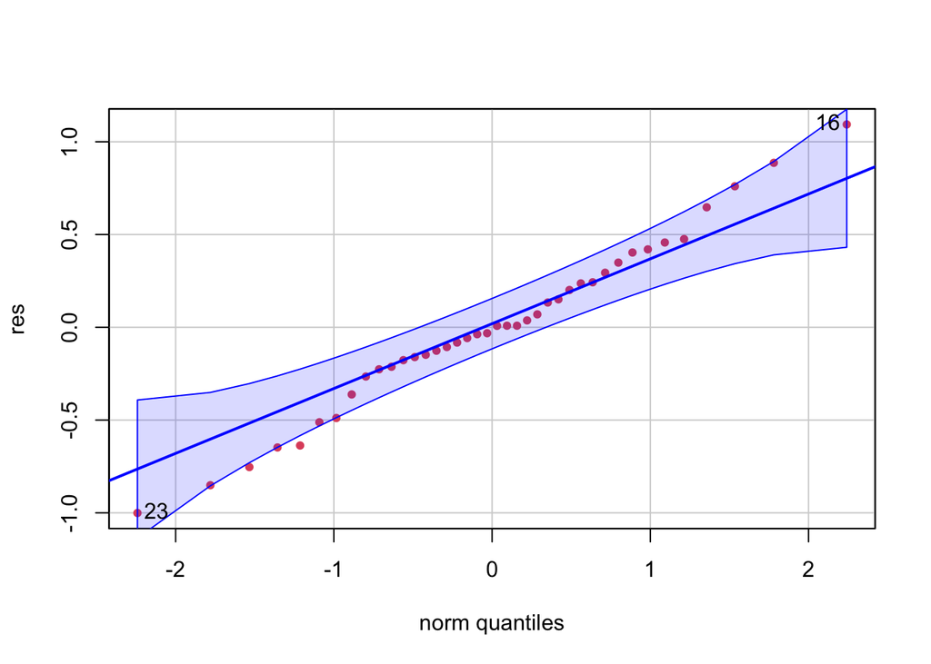

```
## [1] 16 23
```

```r
res <- residuals(mod.waste)

car::qqPlot(res, main = NA, pch = 19, col = 2, cex = 0.7)
```

```r
skew <- skewness(res)
cat("skewness of the residuals -> ", skew)
```

```
## skewness of the residuals ->  0.06108552
```

```r
shapiro.test(res)
```

```
##
##  Shapiro-Wilk normality test
##
## data:  res
## W = 0.98753, p-value = 0.9318
```

**Residuals of the model were normally distributed** and we can confirm from the above qq-plot we also statistically confirmed by the Shapiro-wilk test as its p-value accepting the null hypothesis of normality by its p-value greater than the level of significance

2.b.

Below code indicates the studentized residuals

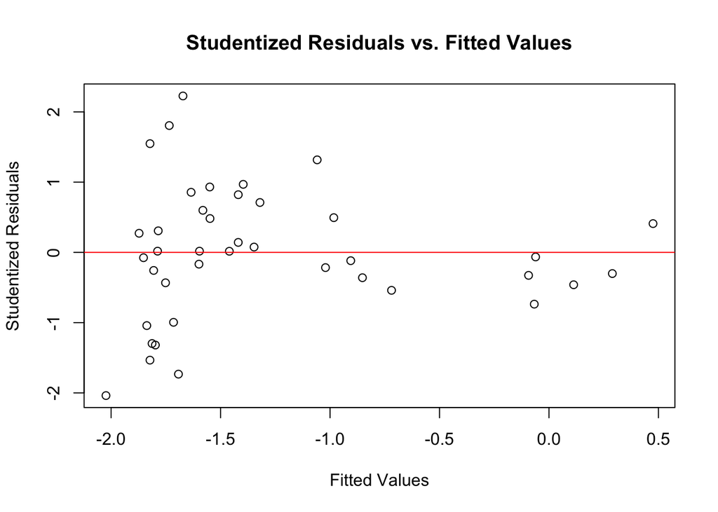

```r
#we need to calcualte the studentised residuals to get the intervals
sigma_residuals <- sigma(mod.waste)
studentized_residuals <- res / sigma_residuals

plot(fitted(mod.waste), studentized_residuals, xlab = "Fitted Values", ylab = "Studentized Residuals",
     main = "Studentized Residuals vs. Fitted Values")
abline(h = 0, col = "red")
```

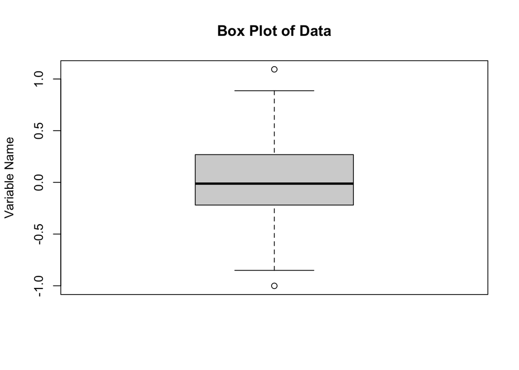

```r
boxplot(res, main = "Box Plot of Data", ylab = "Variable Name")
```

```r
extpts <- which(abs(residuals(mod.waste)) > 3*sd(residuals(mod.waste)))

extpts
```

```
## named integer(0)
```

From the above studentized residuals plot we can observe that the most of the data points were lied at the 0 line and in the range of 2, -2 one on of the point was little above to 2 however it is negligible with 95% significance and can confirm that the model is reasonable. From the box plot we can observe two of the outliers whereas after applying the standard deviation 3 times with the residuals with the abs the result is 0 and so we can confirm that there is no effect of the outliers on the model which generally misleads the model.

2.c

Following code figures out the leverage points on the X-axis which are the explanatory variables

```r
n <- nrow(waste)
p <- ncol(waste)-1
(hilev <- which(influence(mod.waste)$hat > max(2*(p+1)/n,0.5)))
```

```
##  2 15 31 40
##  2 15 31 40
```

Following code plots the leverage points

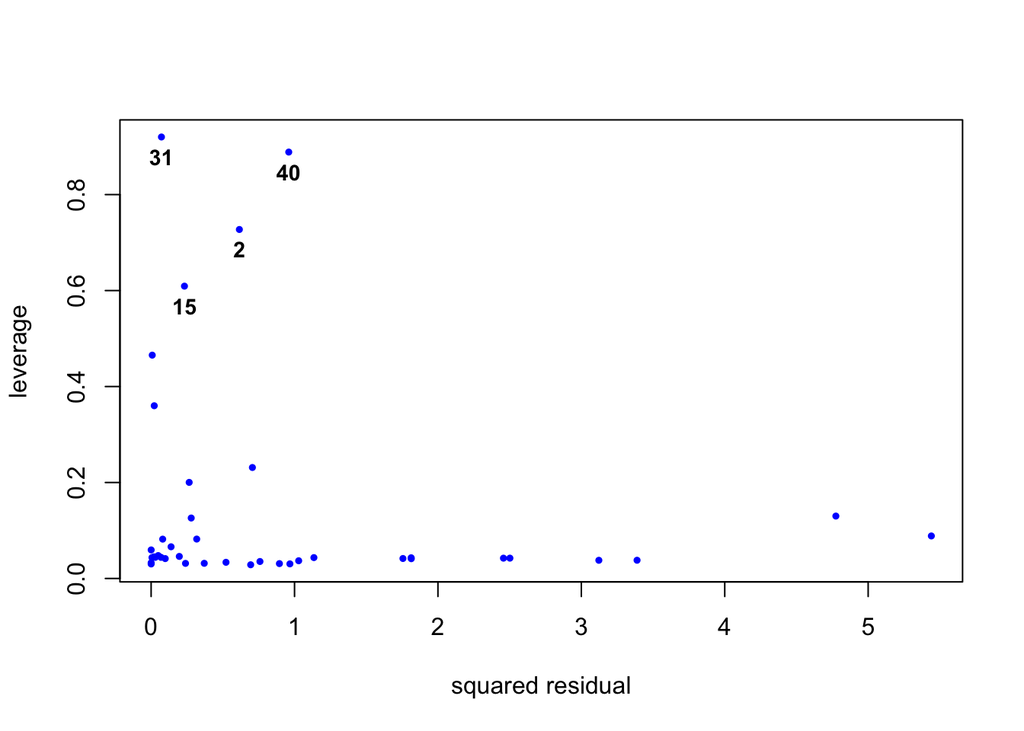

```r
par(mfrow=c(1,1))
plot(rstandard(mod.waste)^2, influence(mod.waste)$hat, pch =19, cex=0.5, col="blue",
     xlab = "squared residual", ylab = "leverage")
inf0 <- which(influence(mod.waste)$hat > 0.5)
text(rstandard(mod.waste)[hilev]^2, influence(mod.waste)$hat[hilev],
     labels = inf0, cex = 0.9, font =2, pos =1)
```

from the above plot we can find the leverage points from the 0 line where as the points far from them may show some effect on the model however neither outliers nor leverage points necessarily influential. To know the influence of them on the model we have several other tests such as Cook’s distance, DFFITS, DFBETAS and following code implements them.

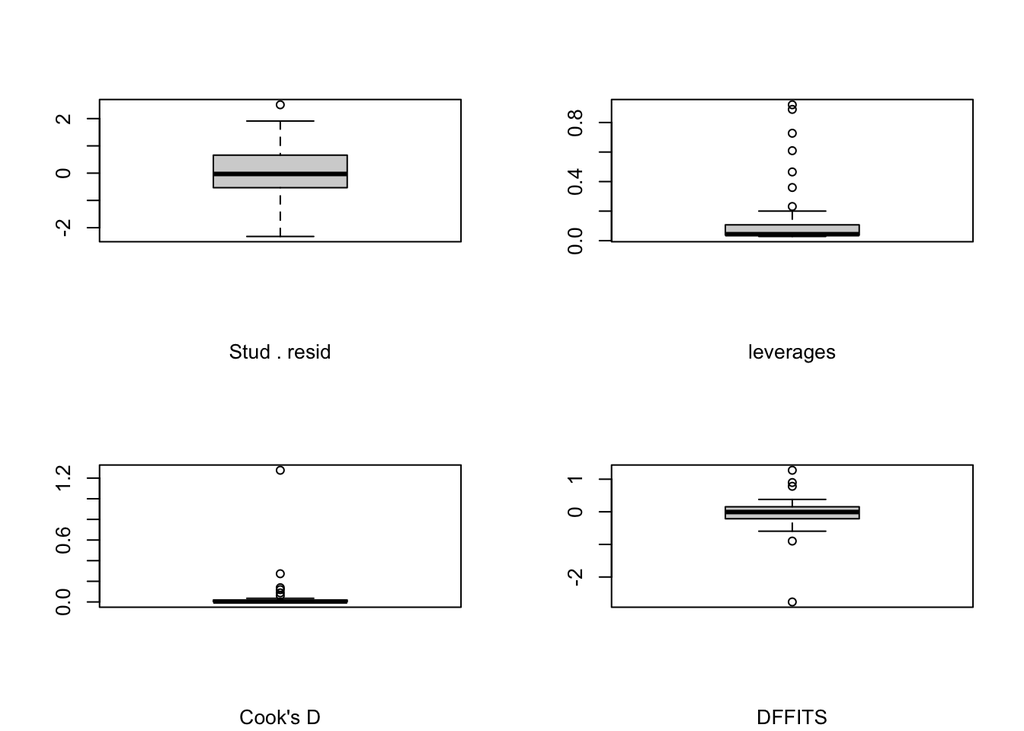

```r
par(mfrow=c(2,2))
boxplot (rstudent (mod.waste), sub =" Stud . resid ")
boxplot (influence(mod.waste)$hat , sub=" leverages ")
boxplot(cooks.distance(mod.waste), sub = "Cook's D")
boxplot(dffits(mod.waste), sub = "DFFITS")
```

From the above plot of cook’s Distance we can observe an outlier which indicates that it is largely effecting the model and by removing it results of the model could change and same applies to the dffits where there is an oulier below to the 0 beyond -2.

[figure not shown]

```r
dfbetas.all  <- as.data.frame(dfbetas(mod.waste))
par(mfrow = c(2,3))
boxplot(dfbetas.all[,1], sub ="Land")
boxplot(dfbetas.all[,2], sub ="Metals")
boxplot(dfbetas.all[,3], sub ="Trucking")
boxplot(dfbetas.all[,4], sub ="Retail")
boxplot(dfbetas.all[,5], sub ="Restaurants")
```

From the above bfbeats plots we can conclude that the points lies close to the 0 has no significnace on the model and removing them will not effect the results where are the values beyond the 1 will have effect on the model and removing the values can effect the model.

Vif which is popularly known as variance inflation factor indicates the multicolinearity between the explanatory variables where higher than the values of a variable tells us that it is higlhyl corelated with the other predictors and removing it can improve the model fit.

```r
library("olsrr")
car::vif(mod.waste)
```

```
##        Land      Metals    Trucking      Retail Restaurants
##    1.415870    5.625816    6.786948    8.310634    7.712421
```

```r
(mod.condind <- ols_eigen_cindex(mod.waste)[,2])
```

```
## [1] 1.000000 1.801381 2.338051 2.659971 7.079740 9.310190
```

```r
(mod.condnum <- max(mod.condind)/min(mod.condind))
```

```
## [1] 9.31019
```

In ridge regression, we minimize the error sum of squares function $S(\beta_1,\ldots, \beta_p)$ subject to a penalty function denoted by

$$\lambda \parallel \boldsymbol{\beta} \parallel^2 =
\lambda \sum_{j=1}^p \beta_j^2$$
{#eq-ridgepenalty}

We need to pass a matrix to the glmnet, lambda values needs to be selected manaually and we have taken 100 for sample and the result is 29.676

```r
library(glmnet)
pred.mat <- as.matrix(waste) # predictors
resp <- waste$SolidWaste # response

mod.ridge.1=glmnet(pred.mat, resp, alpha = 0, standardize=FALSE)
(lambda.m  <- mod.ridge.1$lambda[100])
```

```
## [1] 29.6761
```

```r
coef(mod.ridge.1, s= lambda.m)
```

```
## 8 x 1 sparse Matrix of class "dgCMatrix"
##                        s1
## (Intercept) -1.801142e+00
## Land        -4.771037e-05
## Metals       1.114272e-03
## Trucking    -1.429811e-04
## Retail      -1.752149e-03
## Restaurants  2.772794e-02
## SolidWaste   6.573799e-03
## SolidWaster  1.542256e-03
```

From the above results we see all the variables as according to the rigid mechanism it takes all the variables of the dataset

The glmnet package allows us to select the best lambda value using K-fold cross-validation, by minimizing a user selected criterion, such as MSE. We use 10-fold validation below.

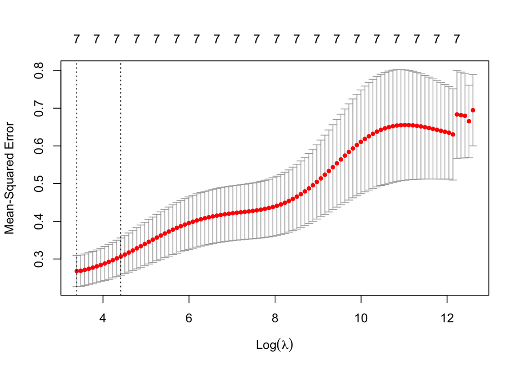

```r
cvfit.ridge <- cv.glmnet(pred.mat,resp,alpha=0, standardize=FALSE,
                         type.measure = "mse", nfolds = 10)
plot(cvfit.ridge)
```

```r
cvfit.ridge$lambda.min
```

```
## [1] 29.6761
```

Following are the intercept values for min lambda value dtermined above

```r
coef(cvfit.ridge, s = "lambda.min")
```

```
## 8 x 1 sparse Matrix of class "dgCMatrix"
##                        s1
## (Intercept) -1.801142e+00
## Land        -4.771037e-05
## Metals       1.114272e-03
## Trucking    -1.429811e-04
## Retail      -1.752149e-03
## Restaurants  2.772794e-02
## SolidWaste   6.573799e-03
## SolidWaster  1.542256e-03
```

Or, we can select the lambda value which gives the most regularized model such that the cross-validated error is within one standard error of the minimum. We obtain the ridge regression coefficients corresponding to lambda.1se:

```r
cvfit.ridge$lambda.1se
```

```
## [1] 82.5755
```

```r
coef(cvfit.ridge, s = "lambda.1se")
```

```
## 8 x 1 sparse Matrix of class "dgCMatrix"
##                        s1
## (Intercept) -1.765464e+00
## Land        -2.309045e-05
## Metals       1.052405e-03
## Trucking    -1.560132e-04
## Retail      -4.664580e-04
## Restaurants  1.920384e-02
## SolidWaste   2.716996e-03
## SolidWaster  6.791898e-04
```

Binded both the values of lambda min as well as 1se

```r
(all.coef <- cbind(coef(cvfit.ridge, s = "lambda.min"),
                   coef(cvfit.ridge, s = "lambda.1se")))
```

```
## 8 x 2 sparse Matrix of class "dgCMatrix"
##                        s1            s1
## (Intercept) -1.801142e+00 -1.765464e+00
## Land        -4.771037e-05 -2.309045e-05
## Metals       1.114272e-03  1.052405e-03
## Trucking    -1.429811e-04 -1.560132e-04
## Retail      -1.752149e-03 -4.664580e-04
## Restaurants  2.772794e-02  1.920384e-02
## SolidWaste   6.573799e-03  2.716996e-03
## SolidWaster  1.542256e-03  6.791898e-04
```

```r
bigmat <- cbind(resp,pred.mat)
mod.ridge.new <- MASS::lm.ridge(resp ~ ., as.data.frame(bigmat))
```

We can interpret the intercepts of the predictors as well as the response variabels

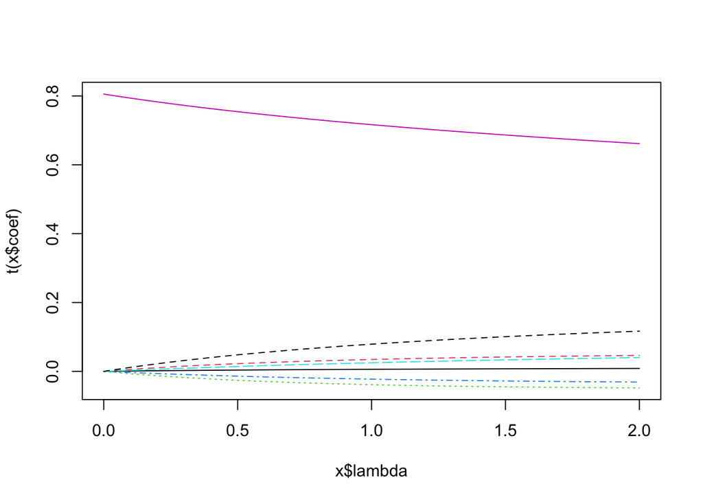

```r
plot(lm.ridge(resp ~ ., as.data.frame(bigmat), lambda = seq(0,2,0.05)))
```